# CSCI E-63C: Week 6 Problem Set

# Problem 2: K-means clustering (20 points)

The goal of this problem is to practice use of K-means clustering and in the process appreciate the variability of the results due to different random starting assignments of observations to clusters and the effect of parameter `nstart` in alleviating it.

## Sub-problem 2a: k-means clusters of different size (5 points)

Using function `kmeans` perform K-means clustering on *explicitly scaled* (e.g. `kmeans(scale(x),2)`) WHS data for 2, 3 and 4 clusters. Use `cluster` attribute in the output of `kmeans` to indicate cluster membership by color and/or shape of the corresponding symbols in the plot of the first two principal components generated independently on the same (scaled WHS) data. E.g. `plot(prcomp(xyz)$x[,1:2],col=kmeans(xyz,4)$cluster)` where `xyz` is input data. Describe the results. Which countries are clustered together for each of these choices of $K$?

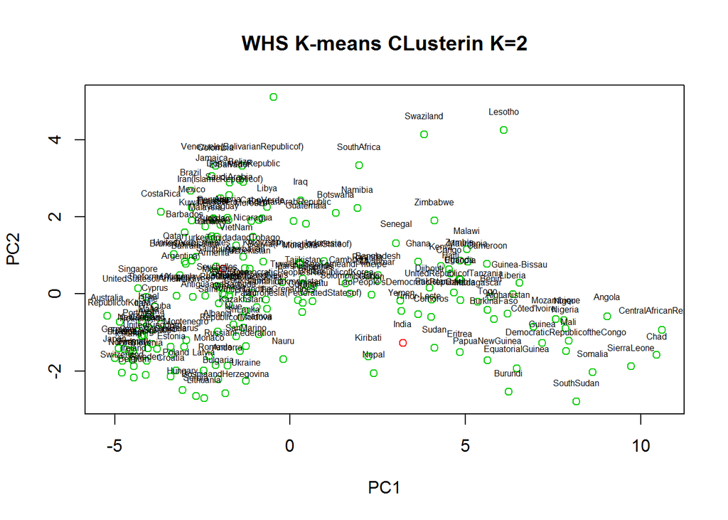

```r
# k-means cluster
km_2 = kmeans(scale(whsAnnBdatNum), 2)
plot(pca_transformed$x[,1:2], col=(km_2$cluster+1), main="WHS K-means CLusterin K=2")
text(x=pr.whs$x[,1], y=pr.whs$x[,2]+0.5, labels=rownames(whsAnnBdatNum), cex=0.5)
```

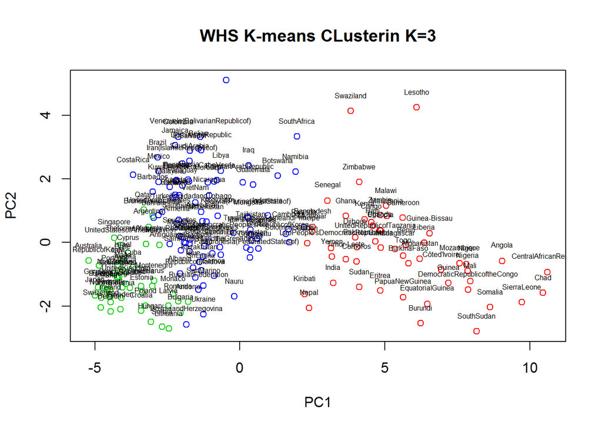

```r
km_3 = kmeans(scale(whsAnnBdatNum), 3)
plot(pca_transformed$x[,1:2], col=(km_3$cluster+1), main="WHS K-means CLusterin K=3")
text(x=pr.whs$x[,1], y=pr.whs$x[,2]+0.5, labels=rownames(whsAnnBdatNum), cex=0.5)
```

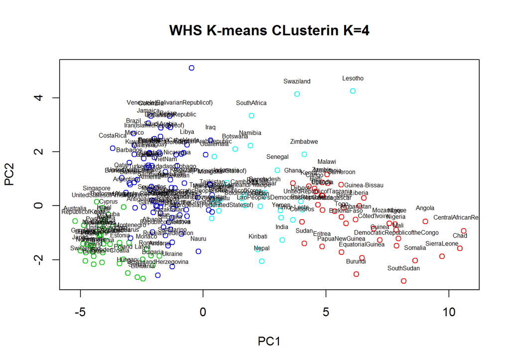

```r
km_4 = kmeans(scale(whsAnnBdatNum), 4)
plot(pca_transformed$x[,1:2], col=(km_4$cluster+1), main="WHS K-means CLusterin K=4")
text(x=pr.whs$x[,1], y=pr.whs$x[,2]+0.5, labels=rownames(whsAnnBdatNum), cex=0.5)
```

## Sub-problem 2b: variability of k-means clustering and effect of `nstart` parameter (15 points)

By default, k-means clustering uses random set of centers as initial guesses of cluster centers. Here we will explore variability of k-means cluster membership across several such initial random guesses. To make such choices of random centers reproducible, we will use function `set.seed` to reset random number generator (RNG) used in R to make those initial guesses to known/controlled initial state.

Using the approach defined above, repeat k-means clustering of *explicitly scaled* WHS data with four (`centers=4`) clusters three times resetting RNG each time with `set.seed` using seeds of 1, 2 and 3 respectively (and default value of `nstart=1`). Indicate cluster membership in each of these three trials on the plot of the first two principal components using color and/or shape as described above. Two fields in the output of `kmeans` – `tot.withinss` and `betweenss` – characterize within and between clusters sum-of-squares. Tighter clustering results are those which have smaller ratio of within to between sum-of-squares. What are the resulting ratios of within to between sum-of-squares for each of these three k-means clustering results (with random seeds of 1, 2 and 3)?

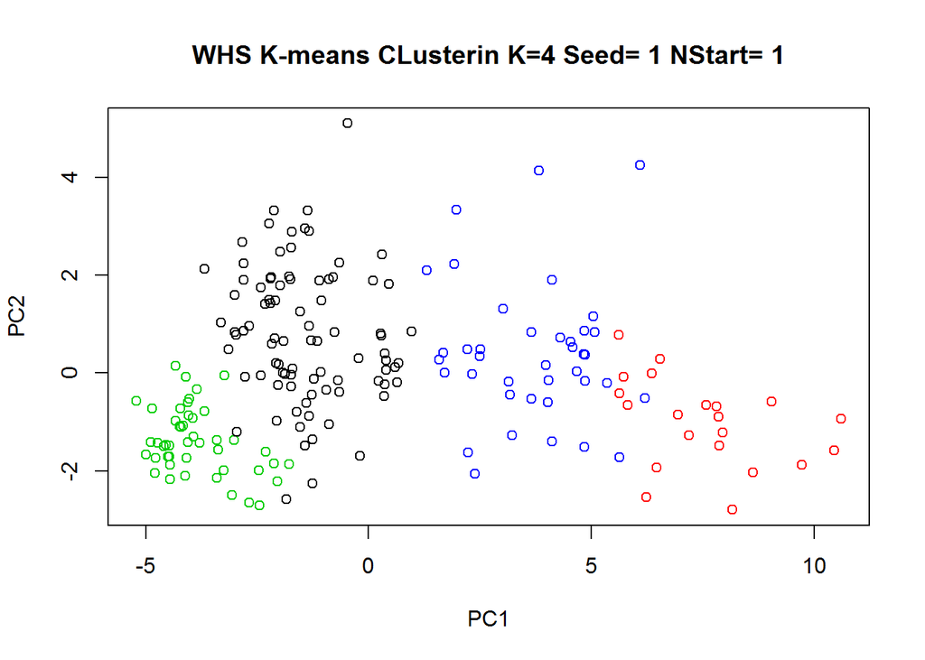

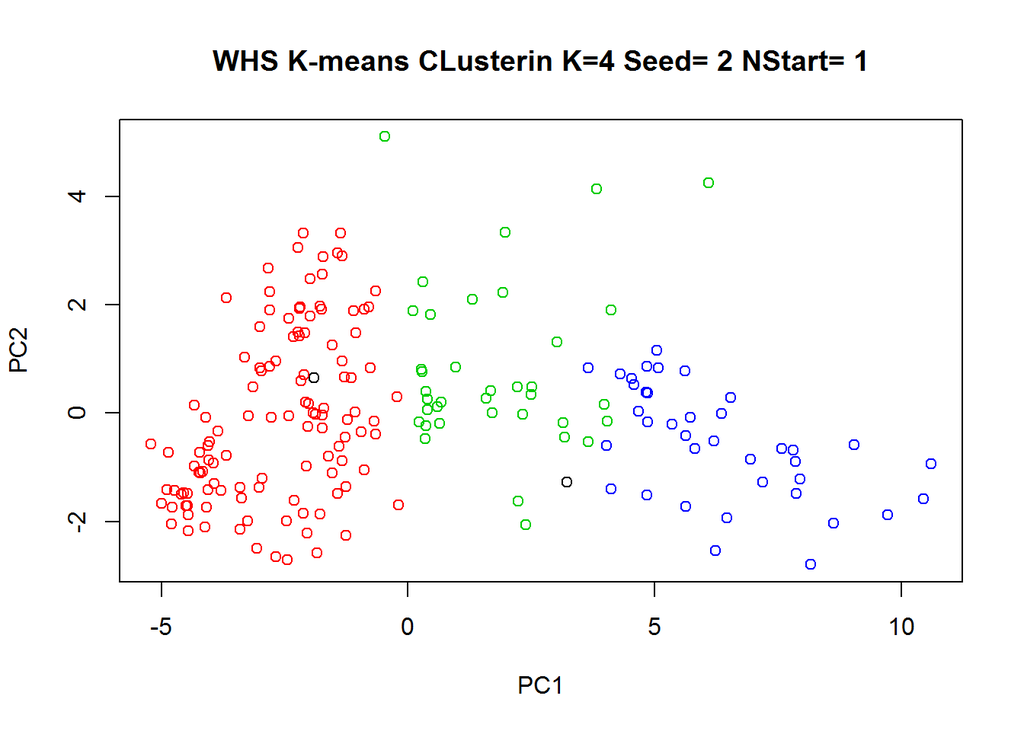

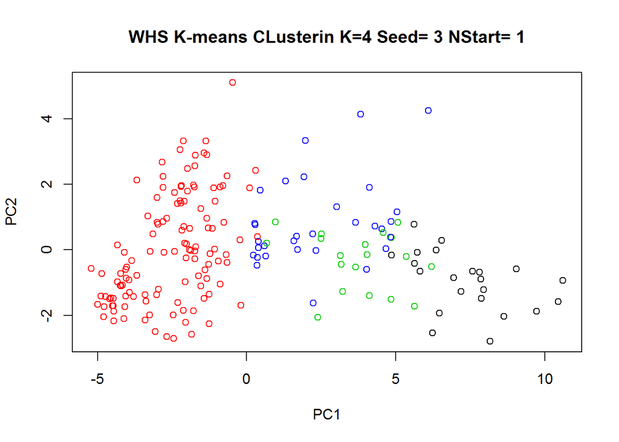

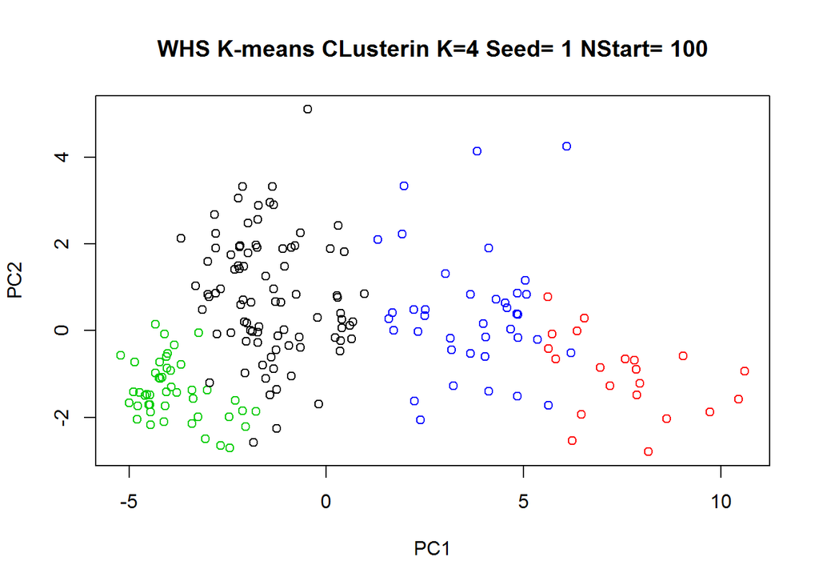

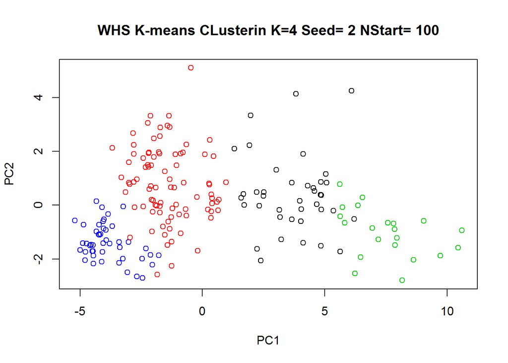

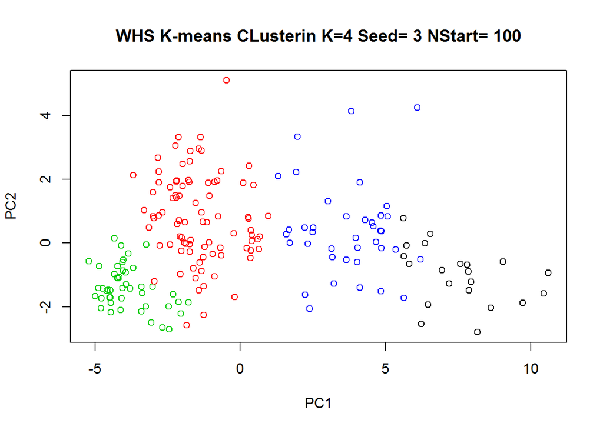

```r
seeds = c(1,2,3)
nstart = c(1, 100)

tot.withinss = numeric()
betweenss = numeric()

for(start in nstart){
  for(seed in seeds){
    set.seed(seed)
    km = kmeans(scale(whsAnnBdatNum), 4, nstart=start)
    plot(pca_transformed$x[,1:2], col=(km$cluster), main=paste("WHS K-means CLusterin K=4", "Seed=", seed, "NStart=",start, sep=" "))
    tot.withinss = c(tot.withinss, km$tot.withinss)
    betweenss = c(betweenss, km$betweenss)
  }
}
```

```r
tot.withinss
```

```
## [1] 4163.212 4254.548 4378.515 4163.212 4163.212 4163.212
```

```r
betweenss
```

```
## [1] 2977.788 2886.452 2762.485 2977.788 2977.788 2977.788
```

```r
# first three ratios are for nstart=1, the last three ratios are for nstart=100
tot.withinss/betweenss # ratio of within to between for seeds 1, 2, and 3
```

```
## [1] 1.398089 1.473971 1.584992 1.398089 1.398089 1.398089
```

Ratios of withiness to betweeness for sum of squares of the clusters: 1.398089 (nstart=1, seed=1) 1.473971 (nstart=1, seed=2) 1.584992 (nstart=1, seed=3) 1.398089 (nstart=100, seed=1) 1.398089 (nstart=100, seed=2) 1.398089 (nstart=100, seed=3)

Please bear in mind that the actual cluster identity is assigned randomly and does not matter – i.e. if cluster 1 from the first run of `kmeans` (with random seed of 1) and cluster 4 from the run with the random seed of 2 contain the same observations (country/states in case of WHS dataset), they are *the same* clusters.

Repeat the same procedure (k-means with four clusters for RNG seeds of 1, 2 and 3) now using `nstart=100` as a parameter in the call to `kmeans`. Represent results graphically as before. How does cluster membership compare between those three runs now? What is the ratio of within to between sum-of-squares in each of these three cases? What is the impact of using higher than 1 (default) value of `nstart`? What is the ISLR recommendation on this offered in Ch. 10.5.1?

Cluster membership does not change or does not seem to change with an nstart=100. According to the kmeans() function, nstart conducts multiple initial configurations that chooses the best centroids from the algrith. It seems that more times this configuration is run (nstart is higher), the more consistent the clsutering becomes as the algorithm/computation agrees on the optimal clustering pattern. The ISLR book recommendeds a large nstart of 20 or 50, likely to provide consistant clustering results. If we look at the ratio of the withiness to betweeness for sum of squares of each cluster, the ratio increases with each seed for nstart=1. This goes against the goal of k-means to minimize the withiness. However, the ratio is constant for all three seeds when nstart=100. We find that setting a higher nstart is more effective at controlling the consistancy of the clustering compared to setting the seed.

One way to achieve everything this sub-problem calls for is to loop over `nstart` values of 1 and 100, for each value of `nstart`, loop over RNG seeds of 1, 2 and 3, for each value of RNG seed, reset RNG, call `kmeans` and plot results for each combination of `nstart` and RNG seed value.

# Problem 3: Hierarchical clustering (15 points)

## Sub-problem 3a: hierachical clustering by different linkages (10 points)

Cluster country states in (scaled) world health statistics data using default (Euclidean) distance and “complete”, “average”, “single” and “ward” linkages in the call to `hclust`. Plot each clustering hierarchy, describe the differences. For comparison, plot results of clustering *untransformed* WHS data using default parameters (Euclidean distance, “complete” linkage) – discuss the impact of the scaling on the outcome of hierarchical clustering.

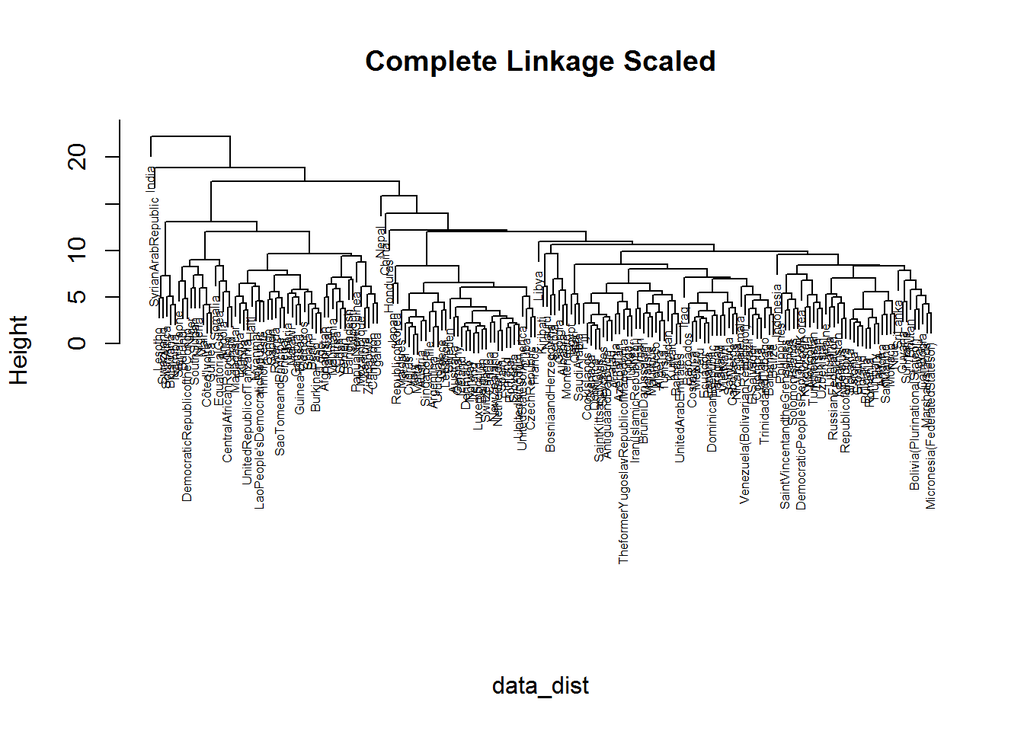

```r
nonscale_dat = whsAnnBdatNum
scale_dat = scale(whsAnnBdatNum)

# hierarchical clustering for scaled data
data_dist = dist(scale_dat, method="euclidean")
hc_complete_sca = hclust(data_dist, method="complete")
hc_average_sca = hclust(data_dist, method="average")
hc_single_sca = hclust(data_dist, method="single")
hc_ward_sca = hclust(data_dist, method="ward.D")

# plot
plot(hc_complete_sca, main="Complete Linkage Scaled", xlab=NULL, sub="", cex=0.5)
```

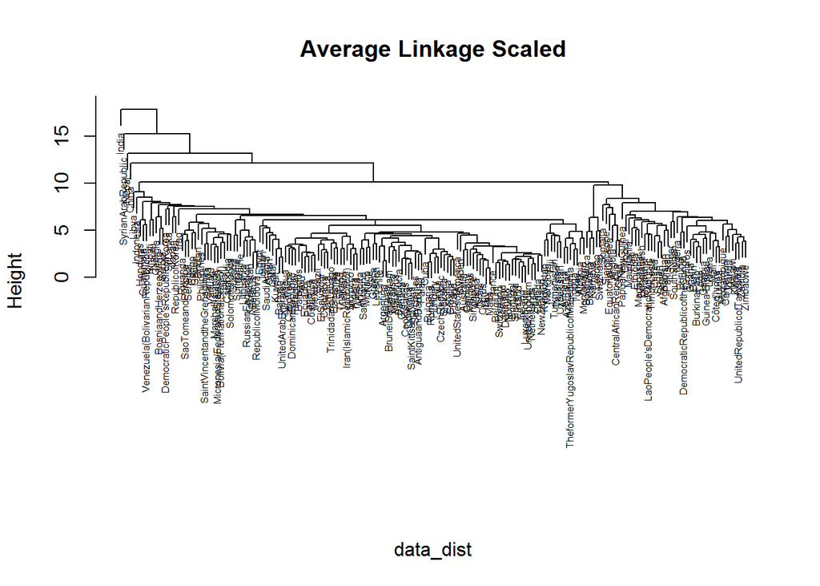

```r
plot(hc_average_sca, main="Average Linkage Scaled", xlab=NULL, sub="", cex=0.5)
```

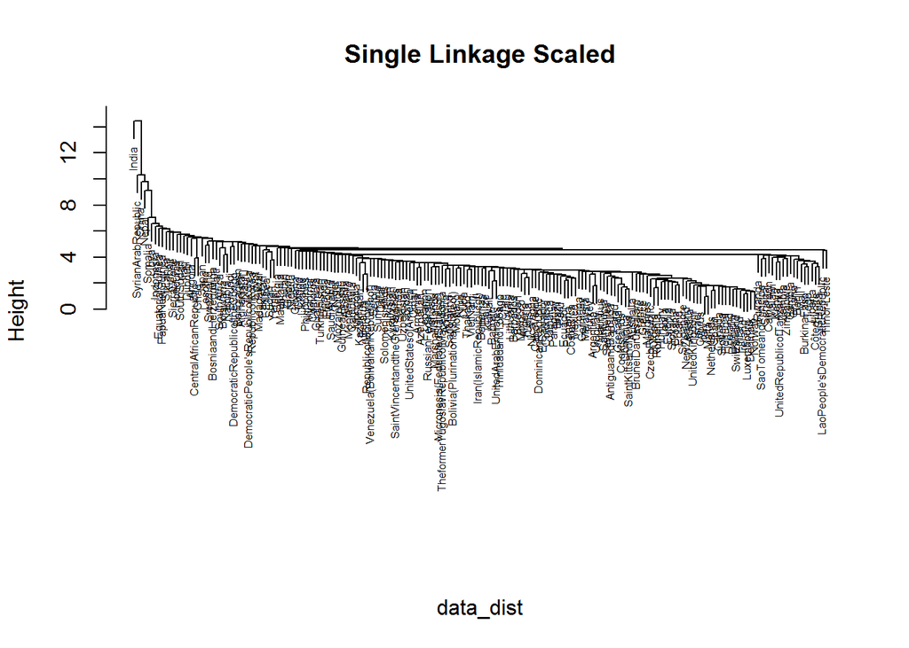

```r
plot(hc_single_sca, main="Single Linkage Scaled", xlab=NULL, sub="", cex=0.5)
```

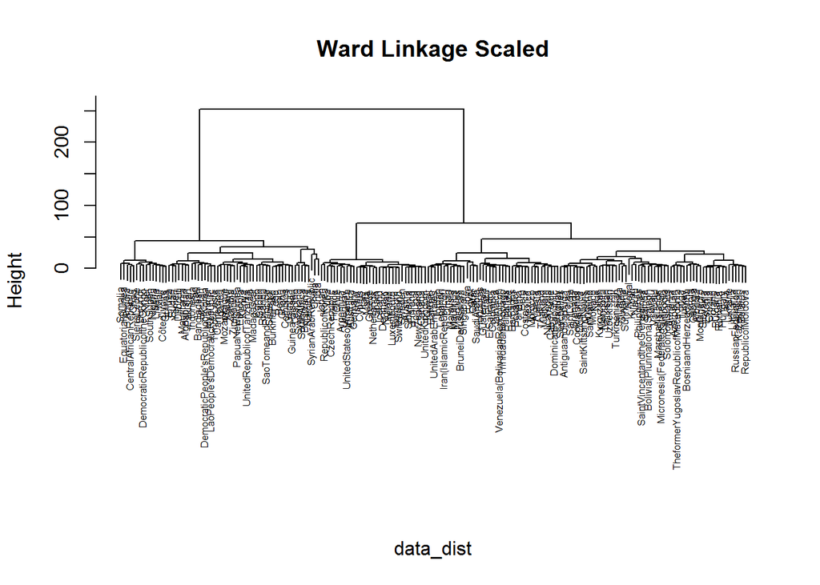

```r
plot(hc_ward_sca, main="Ward Linkage Scaled", xlab=NULL, sub="", cex=0.5)
```

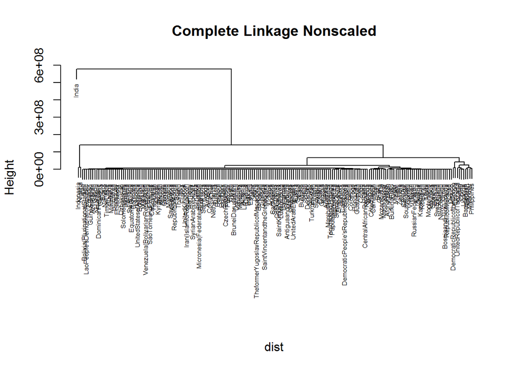

```r
# hierarchical clustering for unscaled data
dist = dist(nonscale_dat, method="euclidean")
hc.complete = hclust(dist, method="complete")
hc.average = hclust(dist, method="average")
hc.single = hclust(dist, method="single")
hc.ward = hclust(dist, method="ward.D")

# plot
plot(hc.complete, main="Complete Linkage Nonscaled", xlab=NULL, sub="", cex=0.5)
```

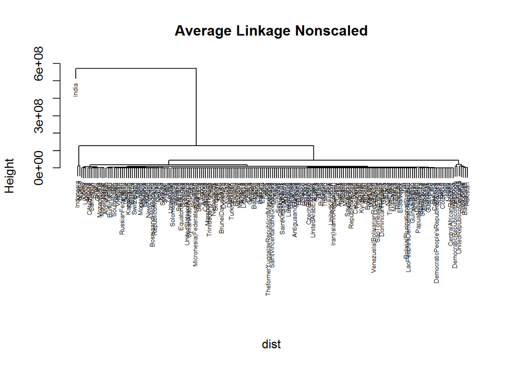

```r
plot(hc.average, main="Average Linkage Nonscaled", xlab=NULL, sub="", cex=0.5)
```

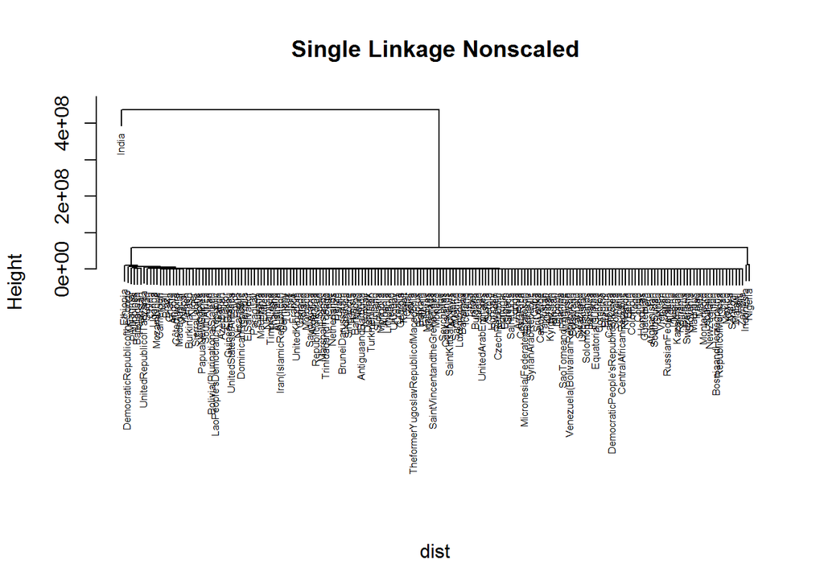

```r
plot(hc.single, main="Single Linkage Nonscaled", xlab=NULL, sub="", cex=0.5)
```

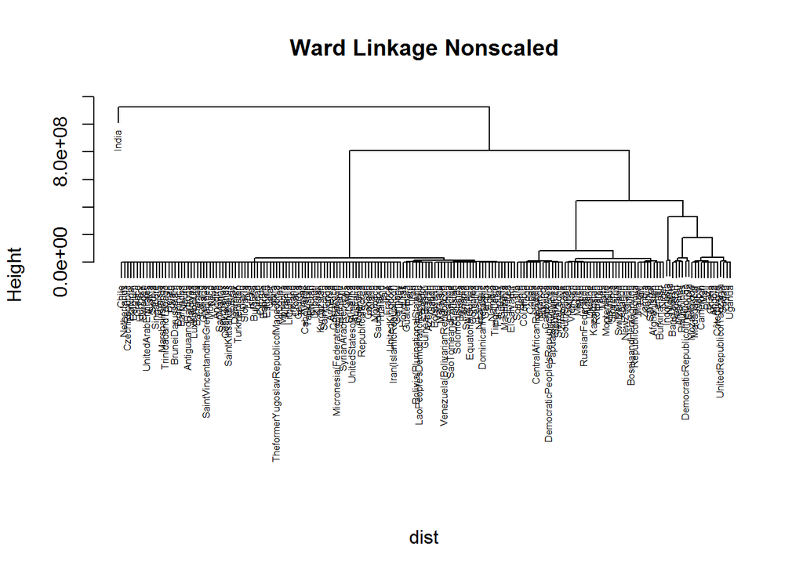

```r
plot(hc.ward, main="Ward Linkage Nonscaled", xlab=NULL, sub="", cex=0.5)
```

When comparing each scaled method with its unscaled counterpart, we see that the effect of scaling helps balance the cluster sizes. The last four plots for unscaled data place almost all the observations into a single cluster or two as k increases, with a separate outlier cluster for India. On the otherhand, scaling tries to create balanced clusters as k increases, based on each method type. And we see typical behavior in the scaled data with Single linkage linking one large cluster together and having a much smaller cluster counterpart. Complete provides several distinct clusters that are balanced in size for higher k’s. And average gives an intermediate structure of the two. Ward also has a balance that splits into multiple clusters after the intial split of two clusters.

## Sub-problem 3b: compare k-means and hierarchical clustering (5 points)

Using function `cutree` on the output of `hclust` determine assignment of the countries in WHS dataset into top four clusters when using Euclidean distance and “complete” linkage. Use function `table` to compare membership of these clusters to those produced by k-means clustering with four clusters in the Problem 2(b) when using `nstart=100` (and any of the RNG seeds) above. Discuss the results.

```r
hc_4 = cutree(hc_complete_sca, 4)
# k-means k = 4, nstart=100
set.seed(4)
km_4 = kmeans(scale(whsAnnBdatNum), 4, nstart=100)
km4_cluster = km_4$cluster

table(hc_4)
```

```
## hc_4
##   1   2   3   4
##  55 137   1   1
```

```r
table(km4_cluster)
```

```
## km4_cluster
##  1  2  3  4
## 39 46 88 21
```

The membership counts for each of the four clusters of data are listed in the tables above. The first table is the membership for Hierarchical Clustering with four clusters, k=4. The second table is the membership coutns for k-Means Clustering with four clusters, k=4 and nstart=100. First it is interesting to note the spread on the Hierarchical method. Almost all the points are concentrated within the first two clusters, 55 and 137, and only one point each for cluster three and four. We knew previously from the graph that one of these solo point clusters contains India, which has been classified by the clustering algorithm to have distinct features that make the nation an outlier. We can also make out that another solo cluster belongs to the SyrianArabRepublic making it the other outlier.

With the k-Means Clustering method, we see the membership more evenly distributed among the clusters compared to Hierarchical Clustering. Cluster three had the largest membership count but does not consist of a majority of the data. Based on these counts, we can see that Hierarchical Clustering method is susceptible to the influence of outliers when constructing the clusters. However, we can see in the graph for Complete clustering that as the k gets larger, the membership sizes even out. And it is important to pay attention to the outlier clusters and what sort of information we can extract about single members such as India or SyrianArabRepublic. Such as what defining attributes warrant their own cluster. And we also see that using k-Means can be beneficial for looking at large group similarities. These may be more general attributes that separate a sizeable group of nations from another, but are blanket characteristics applicable to a certain class of nations.

# Appendix: pre-processing of WHS data

For your reference only – the file it has generated is already available at our course website

```r
whsAnnBdat <- read.table("../data/whs2016_AnnexB-data.txt",sep="\t",header=T,as.is=T,quote="")
dim(whsAnnBdat)
whsAnnBdat <- apply(whsAnnBdat,2,function(x)gsub(">","",gsub("<","",gsub(" ","",x))))
whsAnnBdat <- apply(whsAnnBdat,2,function(x){x[x==rawToChar(as.raw(150))]<-"";x})
rownames(whsAnnBdat) <- whsAnnBdat[,1]
whsAnnBdat <- whsAnnBdat[,-1]
whsAnnBdatNum <- apply(whsAnnBdat,2,as.numeric)
whsAnnBdatNum <- apply(whsAnnBdatNum,2,function(x){x[is.na(x)] <- mean(x,na.rm = TRUE);x})
rownames(whsAnnBdatNum) <- rownames(whsAnnBdat)
write.table(whsAnnBdatNum,"../data/whs2016_AnnexB-data-wo-NAs.txt",quote=F,sep="\t")
```